# Sarcasm_Detection

[figure not shown]

### Package Version:

- tensorflow==2.2.0
- pandas==1.0.5
- numpy==1.18.5
- google==2.0.3

# Sarcasm Detection

### Dataset

#### Acknowledgement

Misra, Rishabh, and Prahal Arora. "Sarcasm Detection using Hybrid Neural Network." arXiv preprint arXiv:1908.07414 (2019).

**Required Files given in below link.**

https://drive.google.com/drive/folders/1xUnF35naPGU63xwRDVGc-DkZ3M8V5mMk

```python
from google.colab import drive
drive.mount('/content/drive/')
```

### Load Data (5 Marks)

```python
import pandas as pd
import numpy as np
import matplotlib.pyplot as plt
df = pd.read_json('/content/drive/MyDrive/k/NLP/sarcasm detection/Copy of Sarcasm_Headlines_Dataset.json',lines=True)
```

```python
df.head()
```

|  | article_link | headline | is_sarcastic |
| --- | --- | --- | --- |
| 0 | https://www.huffingtonpost.com/entry/versace-b... | former versace store clerk sues over secret 'b... | 0 |
| 1 | https://www.huffingtonpost.com/entry/roseanne-... | the 'roseanne' revival catches up to our thorn... | 0 |
| 2 | https://local.theonion.com/mom-starting-to-fea... | mom starting to fear son's web series closest ... | 1 |
| 3 | https://politics.theonion.com/boehner-just-wan... | boehner just wants wife to listen, not come up... | 1 |
| 4 | https://www.huffingtonpost.com/entry/jk-rowlin... | j.k. rowling wishes snape happy birthday in th... | 0 |

### Drop `article_link` from dataset (5 Marks)

```python
df = df.drop(['article_link'],axis=1)
```

```python
df.head()
```

|  | headline | is_sarcastic |
| --- | --- | --- |
| 0 | former versace store clerk sues over secret 'b... | 0 |
| 1 | the 'roseanne' revival catches up to our thorn... | 0 |
| 2 | mom starting to fear son's web series closest ... | 1 |
| 3 | boehner just wants wife to listen, not come up... | 1 |
| 4 | j.k. rowling wishes snape happy birthday in th... | 0 |

```python
df['headline'].values
```

```
array(["former versace store clerk sues over secret 'black code' for minority shoppers",
       "the 'roseanne' revival catches up to our thorny political mood, for better and worse",
       "mom starting to fear son's web series closest thing she will have to grandchild",
       ..., 'reparations and obama',
       'israeli ban targeting boycott supporters raises alarm abroad',
       'gourmet gifts for the foodie 2014'], dtype=object)
```

```python
df.shape
```

```
(26709, 2)
```

```python
df['headline'][0]
```

```
"former versace store clerk sues over secret 'black code' for minority shoppers"
```

```python
df.isnull().sum()
```

```
headline        0
is_sarcastic    0
dtype: int64
```

### Get length of each headline and add a column for that (5 Marks)

```python
df['length'] = [len(df['headline'][x]) for x in range(df.shape[0])]
```

```python
df[0:5]
```

|  | headline | is_sarcastic | length |
| --- | --- | --- | --- |
| 0 | former versace store clerk sues over secret 'b... | 0 | 78 |
| 1 | the 'roseanne' revival catches up to our thorn... | 0 | 84 |
| 2 | mom starting to fear son's web series closest ... | 1 | 79 |
| 3 | boehner just wants wife to listen, not come up... | 1 | 84 |
| 4 | j.k. rowling wishes snape happy birthday in th... | 0 | 64 |

```python
max(df['length'])
```

```
254
```

```python
min(df['length'])
```

```
7
```

```python
sum(df['length'])/len(df['length'])
```

```
60.910591935302705
```

### Initialize parameter values

```python
max_features = 10000
maxlen = 20
embedding_size = 50
```

### Apply `tensorflow.keras` Tokenizer and get indices for words (5 Marks)

- Initialize Tokenizer object with number of words as 10000
- Fit the tokenizer object on headline column
- Convert the text to sequence

```python
import tensorflow
```

```python
from tensorflow.keras.preprocessing.text import Tokenizer
from tensorflow.keras.preprocessing.sequence import pad_sequences

tokenizer = Tokenizer(num_words = max_features,split=' ')
tokenizer.fit_on_texts(df['headline'].values)
```

```python
X = tokenizer.texts_to_sequences(df['headline'].values)
```

```python
X[0:2]
```

```
[[307, 678, 3336, 2297, 47, 381, 2575, 5, 2576, 8433],
 [3, 8434, 3337, 2745, 21, 1, 165, 8435, 415, 3111, 5, 257, 8, 1001]]
```

### Pad sequences (5 Marks)

- Pad each example with a maximum length
- Convert target column into numpy array

```python
X = pad_sequences(X,maxlen=maxlen)
```

```python
X[:2]
```

```
array([[   0,    0,    0,    0,    0,    0,    0,    0,    0,    0,  307,
         678, 3336, 2297,   47,  381, 2575,    5, 2576, 8433],
       [   0,    0,    0,    0,    0,    0,    3, 8434, 3337, 2745,   21,
           1,  165, 8435,  415, 3111,    5,  257,    8, 1001]],
      dtype=int32)
```

```python
X.shape
```

```
(26709, 20)
```

```python
y = df['is_sarcastic']
y = np.array(y)
```

```python
y.shape
```

```
(26709,)
```

```python
from sklearn.model_selection import train_test_split
```

```python
x_train,x_test,y_train,y_test = train_test_split(X,y,test_size=0.2,random_state=1)
```

```python
print(x_train.shape)
print(x_test.shape)
```

```
(21367, 20)
(5342, 20)
```

### Vocab mapping

- There is no word for 0th index

```python
tokenizer.word_index
```

```
{'to': 1,
 'of': 2,
 'the': 3,
 'in': 4,
 'for': 5,
 'a': 6,
 'on': 7,
 'and': 8,
 'with': 9,
 'is': 10,
 'new': 11,
 'trump': 12,
 'man': 13,
 'from': 14,
 'at': 15,
 'about': 16,
 'you': 17,
 'this': 18,
 'by': 19,
 'after': 20,
 'up': 21,
 'out': 22,
 'be': 23,
 'how': 24,
 'as': 25,
 'it': 26,
 'that': 27,
 'not': 28,
 'are': 29,
 'your': 30,
 'his': 31,
 'what': 32,
 'he': 33,
 'all': 34,
 'just': 35,
 'who': 36,
 'has': 37,
 'will': 38,
 'more': 39,
 'one': 40,
```

[output cut: 946 more lines]

```
 'website': 987,
 'pick': 988,
 'explains': 989,
 'table': 990,
 'energy': 991,
 'users': 992,
 'feeling': 993,
 'sales': 994,
 'colbert': 995,
 'apparently': 996,
 "let's": 997,
 'amazing': 998,
 'went': 999,
 'budget': 1000,
 ...}
```

### Set number of words

- Since the above 0th index doesn't have a word, add 1 to the length of the vocabulary

```python
num_words = len(tokenizer.word_index) + 1
print(num_words)
```

```
29657
```

### Load Glove Word Embeddings (5 Marks)

```python
EMBEDDING_FILE = '/content/drive/MyDrive/k/NLP/sarcasm detection/Copy of glove.6B.50d.txt'
```

### Create embedding matrix

```python
embeddings = {}
f = open(EMBEDDING_FILE)
for o in f:
    word = o.split(" ")[0]
    print(word)
    embd = o.split(" ")[1:]
    embd = np.asarray(embd, dtype='float32')
    print(embd)
    embeddings[word] = embd


# create a weight matrix for words in training docs
embedding_matrix = np.zeros((num_words, 50))

for word, i in tokenizer.word_index.items():
	embedding_vector = embeddings.get(word)
	if embedding_vector is not None:
		embedding_matrix[i] = embedding_vector
```

[output not shown]

[output cut: 4946 more lines]

[output not shown]

```python
embedding_matrix.shape
```

```
(29657, 50)
```

```python
vocab_len = embedding_matrix.shape[0]
```

### Define model (10 Marks)

- Hint: Use Sequential model instance and then add Embedding layer, Bidirectional(LSTM) layer, flatten it, then dense and dropout layers as required. In the end add a final dense layer with sigmoid activation for binary classification.

```python
from tensorflow.keras.layers import LSTM,Embedding,Flatten,Input,Dense,Bidirectional
from tensorflow.keras.models import Sequential
```

```python
model = Sequential()
model.add(Embedding(input_dim = vocab_len,output_dim = embedding_size,weights = [embedding_matrix],input_length=maxlen,trainable = False))
model.add(Bidirectional(LSTM(100)))
model.add(Flatten())
model.add(Dense(128))
model.add(Dense(64))
model.add(Dense(1,activation='sigmoid'))
print(model.summary())
```

```
Model: "sequential_6"
_________________________________________________________________
Layer (type)                 Output Shape              Param #
=================================================================
embedding_6 (Embedding)      (None, 20, 50)            1482850
_________________________________________________________________
bidirectional_5 (Bidirection (None, 200)               120800
_________________________________________________________________
flatten_5 (Flatten)          (None, 200)               0
_________________________________________________________________
dense_10 (Dense)             (None, 128)               25728
_________________________________________________________________
dense_11 (Dense)             (None, 64)                8256
_________________________________________________________________
dense_12 (Dense)             (None, 1)                 65
=================================================================
Total params: 1,637,699
Trainable params: 154,849
Non-trainable params: 1,482,850
_________________________________________________________________
None
```

### Compile the model (5 Marks)

```python
sgd = tensorflow.keras.optimizers.SGD(learning_rate=0.001,momentum=0.9,decay=0.0001)

model.compile(optimizer=sgd,loss = "binary_crossentropy",metrics=['accuracy'])

earlystop = tensorflow.keras.callbacks.EarlyStopping(patience=5)
red = tensorflow.keras.callbacks.ReduceLROnPlateau(patience=5)
```

### Fit the model (5 Marks)

```python
history = model.fit(x_train,y_train,batch_size=64,epochs=80,validation_data=(x_test,y_test),callbacks=[earlystop,red])
```

```python
model.evaluate(x_test,y_test)
```

```
[0.3666975796222687, 0.838450014591217]
```

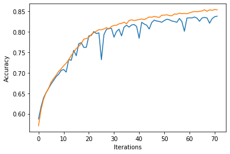

```python
plt.plot(history.history['val_accuracy'])
plt.plot(history.history['accuracy'])
plt.xlabel('Iterations')
plt.ylabel('Accuracy')
plt.show()
```

[figure not shown]

```python
plt.plot(history.history['val_loss'])
plt.plot(history.history['loss'])
plt.xlabel('Iterations')
plt.ylabel('Accuracy')
plt.show()
```